# Bayesian Statistics in R - Data Analysis Project

Nelson Tang

2020-01-20

## Setup

### Load packages

```r
library(ggplot2)
library(dplyr)
library(statsr)
library(BAS)

library(broom)
library(GGally)
library(knitr)
```

### Load data

```r
load("movies.Rdata")
```

## Part 1: Data

Can we understand what will be popular with audiences by looking at movie features? We’ll try to answer this question with a random sample of 651 movies produced and released before 2016, originally sourced through the Rottentomatoes and IMDB API. Specifically, we’ll apply Bayesian Regression techniques to predict the audience score from the data. Since the data is a random sample, we expect the results to be generalizable but we cannot make causal statements due to the lack of random assignment.

```r
head(movies)
```

| title | title_type | genre | runtime | mpaa_rating | studio | thtr_rel_year | thtr_rel_month | thtr_rel_day | dvd_rel_year | dvd_rel_month | dvd_rel_day | imdb_rating | imdb_num_votes | critics_rating | critics_score | audience_rating | audience_score | best_pic_nom | best_pic_win | best_actor_win | best_actress_win | best_dir_win | top200_box | director | actor1 | actor2 | actor3 | actor4 | actor5 | … |
| --- | --- | --- | --- | --- | --- | --- | --- | --- | --- | --- | --- | --- | --- | --- | --- | --- | --- | --- | --- | --- | --- | --- | --- | --- | --- | --- | --- | --- | --- | --- |
| Filly Brown | Feature Film | Drama | 80 | R | Indomina Media Inc. | 2013 | 4 | 19 | 2013 | 7 | 30 | 5.5 | 899 | Rotten | 45 | Upright | 73 | no | no | no | no | no | no | Michael D. Olmos | Gina Rodriguez | Jenni Rivera | Lou Diamond Phillips | Emilio Rivera | Joseph Julian Soria | … |
| The Dish | Feature Film | Drama | 101 | PG-13 | Warner Bros. Pictures | 2001 | 3 | 14 | 2001 | 8 | 28 | 7.3 | 12285 | Certified Fresh | 96 | Upright | 81 | no | no | no | no | no | no | Rob Sitch | Sam Neill | Kevin Harrington | Patrick Warburton | Tom Long | Genevieve Mooy | … |
| Waiting for Guffman | Feature Film | Comedy | 84 | R | Sony Pictures Classics | 1996 | 8 | 21 | 2001 | 8 | 21 | 7.6 | 22381 | Certified Fresh | 91 | Upright | 91 | no | no | no | no | no | no | Christopher Guest | Christopher Guest | Catherine O'Hara | Parker Posey | Eugene Levy | Bob Balaban | … |
| The Age of Innocence | Feature Film | Drama | 139 | PG | Columbia Pictures | 1993 | 10 | 1 | 2001 | 11 | 6 | 7.2 | 35096 | Certified Fresh | 80 | Upright | 76 | no | no | yes | no | yes | no | Martin Scorsese | Daniel Day-Lewis | Michelle Pfeiffer | Winona Ryder | Richard E. Grant | Alec McCowen | … |
| Malevolence | Feature Film | Horror | 90 | R | Anchor Bay Entertainment | 2004 | 9 | 10 | 2005 | 4 | 19 | 5.1 | 2386 | Rotten | 33 | Spilled | 27 | no | no | no | no | no | no | Stevan Mena | Samantha Dark | R. Brandon Johnson | Brandon Johnson | Heather Magee | Richard Glover | … |
| Old Partner | Documentary | Documentary | 78 | Unrated | Shcalo Media Group | 2009 | 1 | 15 | 2010 | 4 | 20 | 7.8 | 333 | Fresh | 91 | Upright | 86 | no | no | no | no | no | no | Chung-ryoul Lee | Choi Won-kyun | Lee Sam-soon | Moo | NA | NA | … |

| title <chr> | title_type <fctr> | genre <fctr> | runtime <dbl> | mpaa_rating <fctr> |  |
| --- | --- | --- | --- | --- | --- |
| Filly Brown | Feature Film | Drama | 80 | R |  |
| The Dish | Feature Film | Drama | 101 | PG-13 |  |
| Waiting for Guffman | Feature Film | Comedy | 84 | R |  |
| The Age of Innocence | Feature Film | Drama | 139 | PG |  |
| Malevolence | Feature Film | Horror | 90 | R |  |
| Old Partner | Documentary | Documentary | 78 | Unrated |  |

6 rows | 1-5 of 32 columns

## Part 2: Data manipulation

Before we do anything, let’s take a look at the data and see if we have to do some data cleaning, like infer missing values. I always start with a `summary()`:

```r
summary(movies)
```

```
##     title                  title_type                 genre
##  Length:651         Documentary : 55   Drama             :305
##  Class :character   Feature Film:591   Comedy            : 87
##  Mode  :character   TV Movie    :  5   Action & Adventure: 65
##                                        Mystery & Suspense: 59
##                                        Documentary       : 52
##                                        Horror            : 23
##                                        (Other)           : 60
##     runtime       mpaa_rating                               studio
##  Min.   : 39.0   G      : 19   Paramount Pictures              : 37
##  1st Qu.: 92.0   NC-17  :  2   Warner Bros. Pictures           : 30
##  Median :103.0   PG     :118   Sony Pictures Home Entertainment: 27
##  Mean   :105.8   PG-13  :133   Universal Pictures              : 23
##  3rd Qu.:115.8   R      :329   Warner Home Video               : 19
##  Max.   :267.0   Unrated: 50   (Other)                         :507
##  NA's   :1                     NA's                            :  8
##  thtr_rel_year  thtr_rel_month   thtr_rel_day    dvd_rel_year
##  Min.   :1970   Min.   : 1.00   Min.   : 1.00   Min.   :1991
##  1st Qu.:1990   1st Qu.: 4.00   1st Qu.: 7.00   1st Qu.:2001
##  Median :2000   Median : 7.00   Median :15.00   Median :2004
##  Mean   :1998   Mean   : 6.74   Mean   :14.42   Mean   :2004
##  3rd Qu.:2007   3rd Qu.:10.00   3rd Qu.:21.00   3rd Qu.:2008
##  Max.   :2014   Max.   :12.00   Max.   :31.00   Max.   :2015
##                                                 NA's   :8
##  dvd_rel_month     dvd_rel_day     imdb_rating    imdb_num_votes
##  Min.   : 1.000   Min.   : 1.00   Min.   :1.900   Min.   :   180
##  1st Qu.: 3.000   1st Qu.: 7.00   1st Qu.:5.900   1st Qu.:  4546
##  Median : 6.000   Median :15.00   Median :6.600   Median : 15116
##  Mean   : 6.333   Mean   :15.01   Mean   :6.493   Mean   : 57533
##  3rd Qu.: 9.000   3rd Qu.:23.00   3rd Qu.:7.300   3rd Qu.: 58300
##  Max.   :12.000   Max.   :31.00   Max.   :9.000   Max.   :893008
##  NA's   :8        NA's   :8
##          critics_rating critics_score    audience_rating audience_score
##  Certified Fresh:135    Min.   :  1.00   Spilled:275     Min.   :11.00
##  Fresh          :209    1st Qu.: 33.00   Upright:376     1st Qu.:46.00
##  Rotten         :307    Median : 61.00                   Median :65.00
##                         Mean   : 57.69                   Mean   :62.36
##                         3rd Qu.: 83.00                   3rd Qu.:80.00
##                         Max.   :100.00                   Max.   :97.00
##
```

[output cut: 17 more lines]

```
##  Length:651         Length:651         Length:651
##  Class :character   Class :character   Class :character
##  Mode  :character   Mode  :character   Mode  :character
##
##
##
##
##    imdb_url            rt_url
##  Length:651         Length:651
##  Class :character   Class :character
##  Mode  :character   Mode  :character
##
##
##
##
```

Thankfully the data is very clean, with no missing values in `audience_score`.

Our rubric tells us to create some new variables:

- feature_film: yes if the movie is a feature film, no otherwise
- drama: yes if the movie is in the drama genre, no otherwise
- mpaa_rating_R: yes if the movie is R-rated, no otherwise
- oscar_season: yes if the movie was released during the so-called ‘oscar season’ from October through December
- summer_season: yes if the movie was released in the summer months

We’ll leverage `dplyr`’s `mutate` function to create these all at once and store them in a new dataframe `movies_clean`

```r
movies_clean <- movies %>%
  mutate(
    feature_film = ifelse(title_type == "Feature Film", "yes", "no"),
    drama = ifelse(genre == "Drama", "yes", "no"),
    mpaa_rating_R = ifelse(mpaa_rating == "R", "yes", "no"),
    oscar_season = ifelse(thtr_rel_month >= 10, "yes", "no"),
    summer_season = ifelse(thtr_rel_month %in% c(5,6,7,8), "yes", "no")
  )
```

## Part 3: Exploratory data analysis

First, since we’re looking to predict our `audience_score` data, we should take a look at the distribution and see if anything odd jumps out at us.

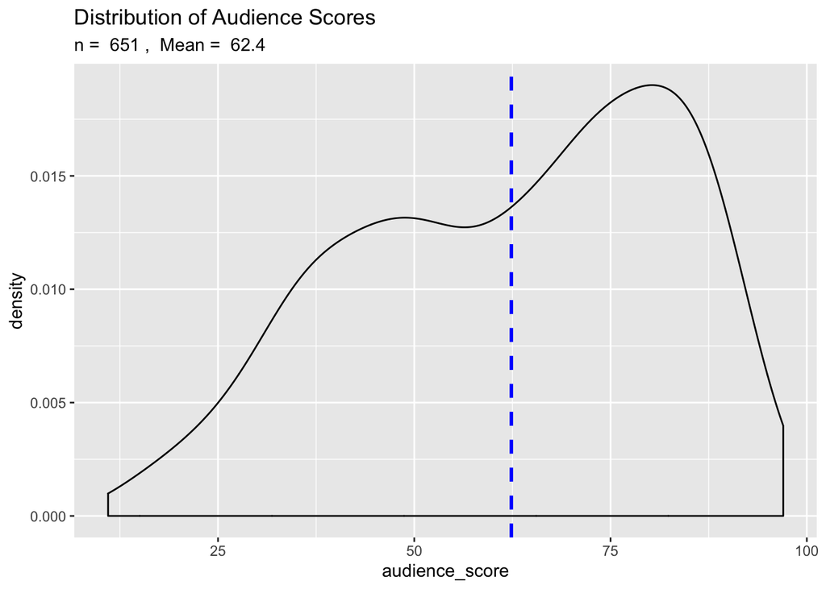

```r
x = round(mean(movies_clean$audience_score),1)
movies_clean %>%
  ggplot(aes(x = audience_score)) +
  geom_density() +
  geom_vline(aes(xintercept=mean(audience_score)), color="blue", linetype="dashed", size=1) +
  labs(title = "Distribution of Audience Scores",
       subtitle = paste("n = ",length(movies_clean$audience_score),", ", "Mean = ", x))
```

We see the distribution is left-skewed, with a peak around 80-85.

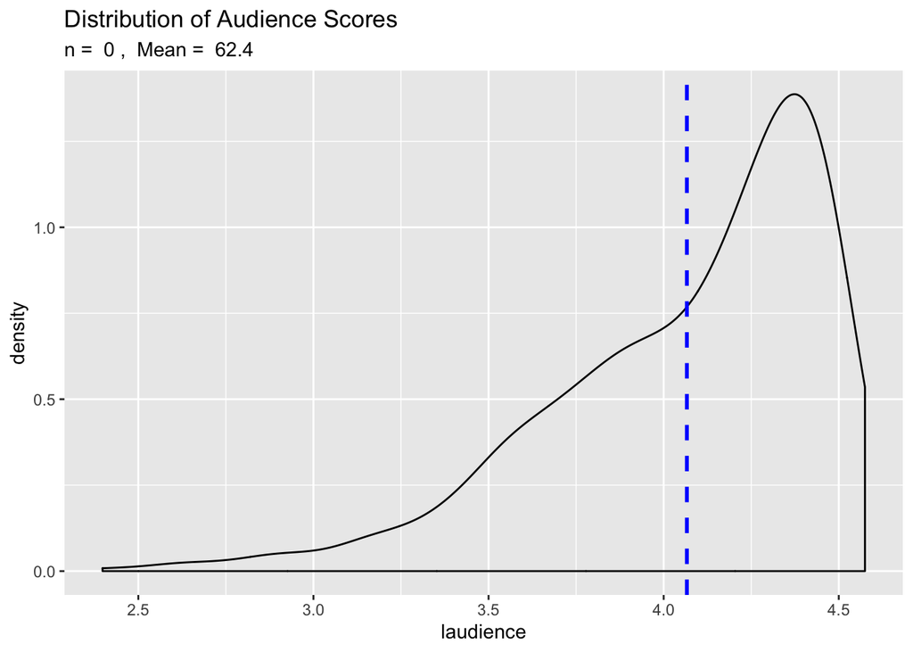

```r
movies_clean %>%
  mutate(laudience = log(audience_score)) %>%
  ggplot(aes(x = laudience)) +
  geom_density() +
  geom_vline(aes(xintercept=mean(laudience)), color="blue", linetype="dashed", size=1) +
  labs(title = "Distribution of Audience Scores",
       subtitle = paste("n = ",length(movies_clean$laudience),", ", "Mean = ", x))
```

Let’s take a look at the relationship between `audience_score` and the 5 new variables that we created in Part 2.

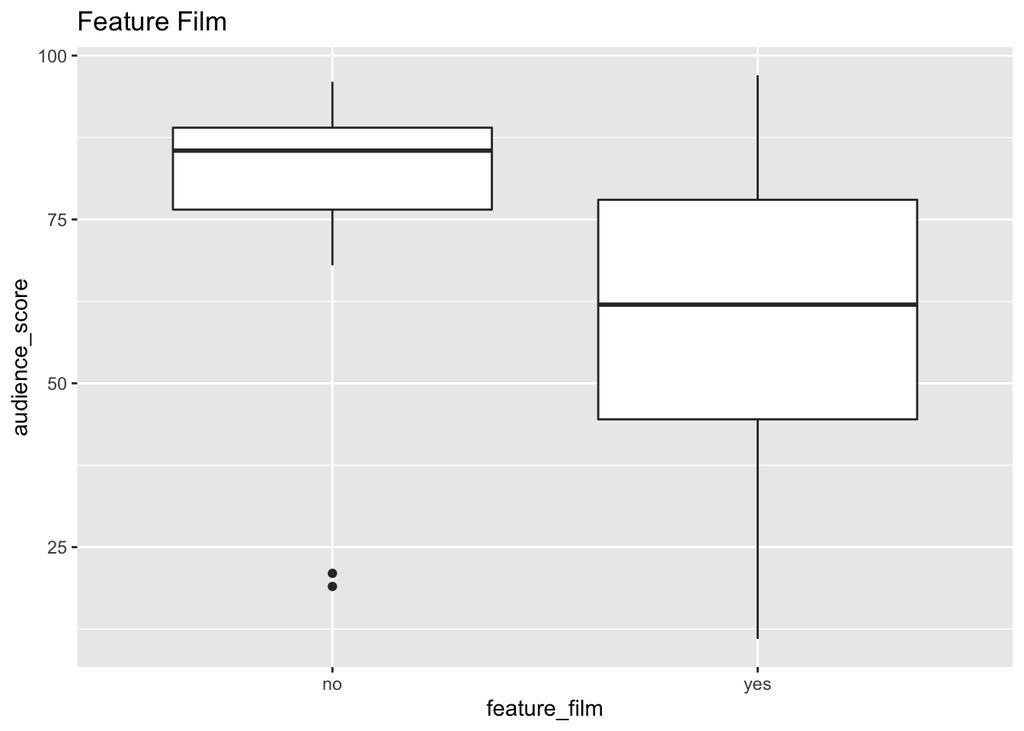

```r
movies_clean %>%
  ggplot(aes(x = feature_film, y = audience_score)) +
  geom_boxplot() +
  labs(title = "Feature Film")
```

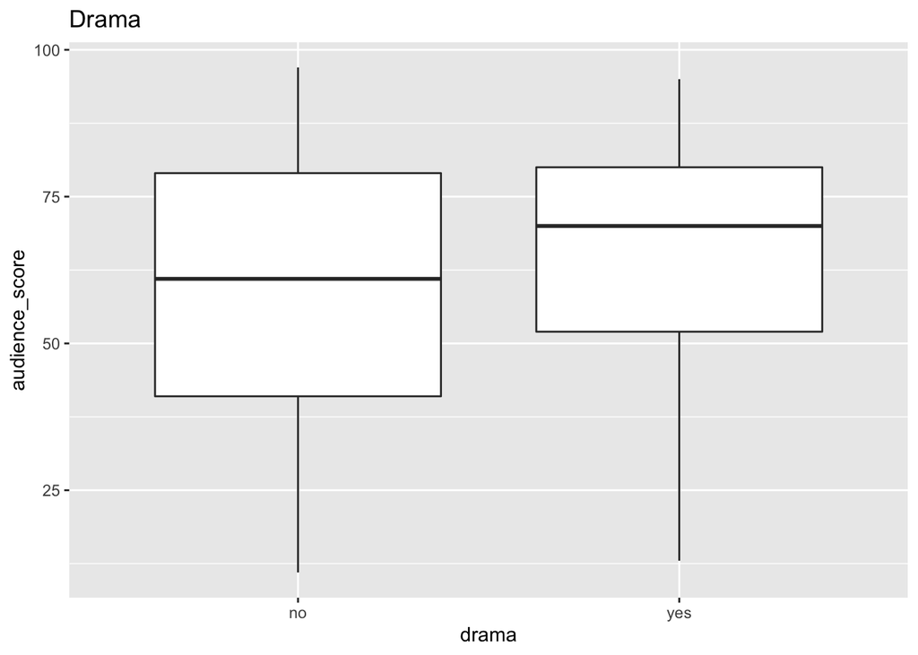

```r
movies_clean %>%
  ggplot(aes(x = drama, y = audience_score)) +
  geom_boxplot() +
  labs(title = "Drama")
```

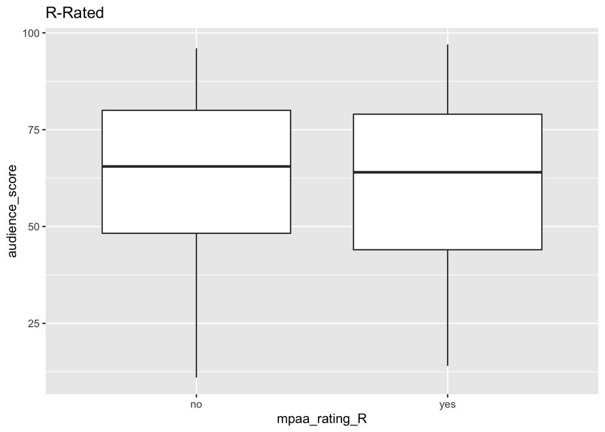

```r
movies_clean %>%
  ggplot(aes(x = mpaa_rating_R, y = audience_score)) +
  geom_boxplot() +
  labs(title = "R-Rated")
```

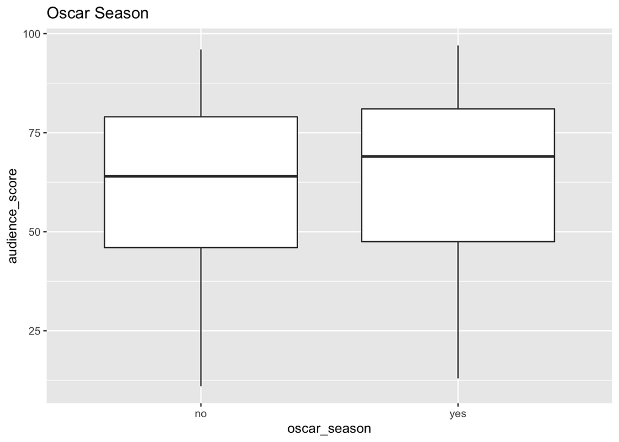

```r
movies_clean %>%
  ggplot(aes(x = oscar_season, y = audience_score)) +
  geom_boxplot() +
  labs(title = "Oscar Season")
```

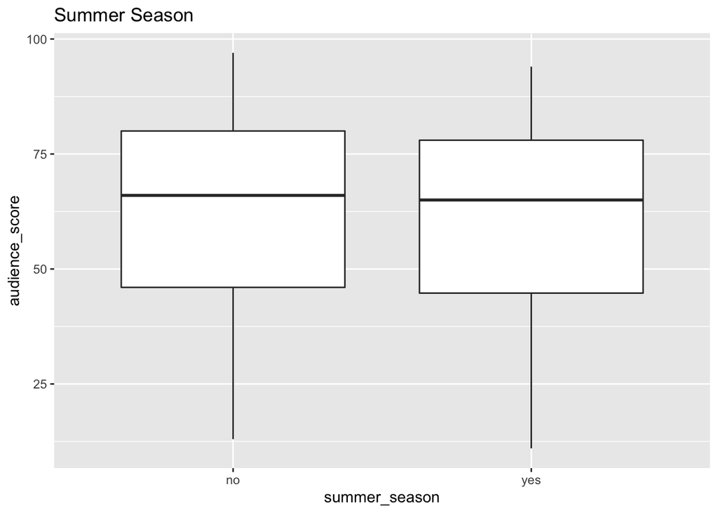

```r
movies_clean %>%
  ggplot(aes(x = summer_season, y = audience_score)) +
  geom_boxplot() +
  labs(title = "Summer Season")
```

We can see some interesting things in the boxplots for Feature Films and Dramas vs Audience Score from our sample. It appears that non-feature films have a higher median audience score than feature films, and dramas have higher median scores than non-dramas. Movies released in oscar season have a slightly higher median score than movies outside of oscar season. R-rating and movies released during the summer season don’t appear to have much of a difference in scores.

```r
table(movies_clean$feature_film)
```

```
##
##  no yes
##  60 591
```

So it’s possible that while `feature_film` == ‘no’ seemed indicative of higher audience scores, it might just be due to the fact that there’s so few of them in our sample.

```r
table(movies_clean$drama)
```

```
##
##  no yes
## 346 305
```

## Part 4: Modeling

Next, we’ll create a Bayesian regression model to predict `audience_score` as a function of our explanatory variables. Per the rubric we already have the variables pre-selected for us, so as a first pass we’ll use OLS to explore a model with all of the required variables:

```r
movies_subset <- movies_clean %>%
  select(feature_film, drama, runtime, mpaa_rating_R, thtr_rel_year, oscar_season, summer_season, imdb_rating, imdb_num_votes,
         critics_score, best_pic_nom, best_pic_win, best_actor_win, best_actress_win, best_dir_win, top200_box, audience_score)
m_audience <- lm(audience_score ~ . , data = movies_subset)
summary(m_audience)
```

```
##
## Call:
## lm(formula = audience_score ~ ., data = movies_subset)
##
## Residuals:
##     Min      1Q  Median      3Q     Max
## -28.594  -6.156   0.157   5.909  53.125
##
## Coefficients:
##                       Estimate Std. Error t value Pr(>|t|)
## (Intercept)          1.244e+02  7.749e+01   1.606  0.10886
## feature_filmyes     -2.248e+00  1.687e+00  -1.332  0.18323
## dramayes             1.292e+00  8.766e-01   1.474  0.14087
## runtime             -5.614e-02  2.415e-02  -2.324  0.02042 *
## mpaa_rating_Ryes    -1.444e+00  8.127e-01  -1.777  0.07598 .
## thtr_rel_year       -7.657e-02  3.835e-02  -1.997  0.04628 *
## oscar_seasonyes     -5.333e-01  9.967e-01  -0.535  0.59280
## summer_seasonyes     9.106e-01  9.493e-01   0.959  0.33778
## imdb_rating          1.472e+01  6.067e-01  24.258  < 2e-16 ***
## imdb_num_votes       7.234e-06  4.523e-06   1.600  0.11019
## critics_score        5.748e-02  2.217e-02   2.593  0.00973 **
## best_pic_nomyes      5.321e+00  2.628e+00   2.025  0.04330 *
## best_pic_winyes     -3.212e+00  4.610e+00  -0.697  0.48624
## best_actor_winyes   -1.544e+00  1.179e+00  -1.310  0.19068
## best_actress_winyes -2.198e+00  1.304e+00  -1.686  0.09229 .
## best_dir_winyes     -1.231e+00  1.728e+00  -0.713  0.47630
## top200_boxyes        8.478e-01  2.782e+00   0.305  0.76067
## ---
## Signif. codes:  0 '***' 0.001 '**' 0.01 '*' 0.05 '.' 0.1 ' ' 1
##
## Residual standard error: 9.975 on 633 degrees of freedom
##   (1 observation deleted due to missingness)
## Multiple R-squared:  0.763,  Adjusted R-squared:  0.757
## F-statistic: 127.3 on 16 and 633 DF,  p-value: < 2.2e-16
```

So it looks like `imdb_rating`, `critics_score`, and `runtime` would be our most predictive features here, with `thtr_rel_year` and `best_pic_nomyes` sitting at the borderline of significance (under the frequentist interpretation).

We should also check the residuals to see if they align with our assumption that the residuals are normally distributed with mean 0:

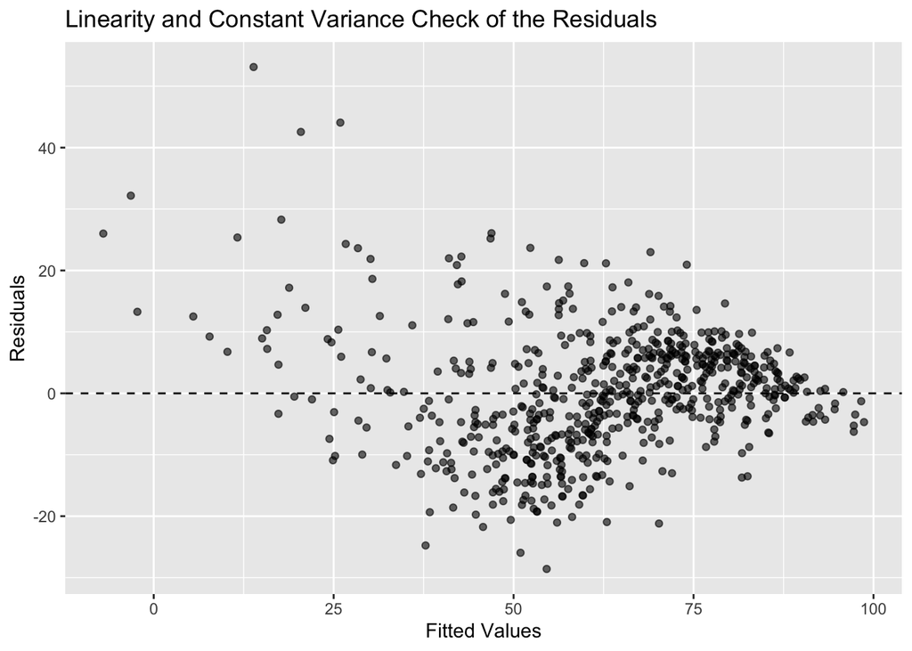

```r
m_audience_aug <- augment(m_audience)
m_audience_aug %>%
  ggplot(aes(x=.fitted, y=.resid)) +
  geom_point(alpha = 0.6) +
  geom_hline(yintercept = 0, linetype = "dashed") +
  labs(x = "Fitted Values", y = "Residuals", title = "Linearity and Constant Variance Check of the Residuals")
```

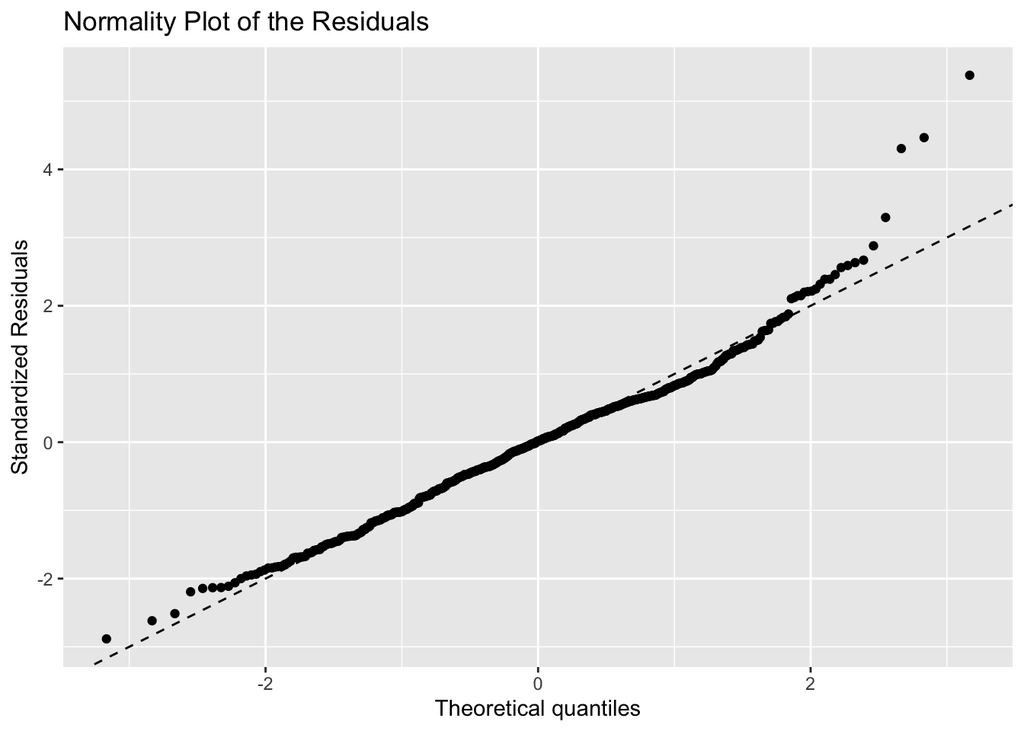

```r
m_audience_aug %>%
  ggplot() +
  geom_qq(aes(sample = .std.resid)) +
  geom_abline(slope = 1, intercept = 0, linetype = "dashed") +
  labs(x = "Theoretical quantiles", y = "Standardized Residuals", title = "Normality Plot of the Residuals")
```

Next we’ll use the `BAS` package to implement **Bayesian model averaging (BMA)**. We’ll use a non-informative reference prior `BIC` for the prior distribution of the coefficients and a uniform distribution for the prior probability of each model.

```r
bma_audience = bas.lm(audience_score ~ ., data = movies_subset,
                 prior = "BIC", modelprior = uniform())
bma_audience
```

```
##
## Call:
## bas.lm(formula = audience_score ~ ., data = movies_subset, prior = "BIC",
##     modelprior = uniform())
##
##
##  Marginal Posterior Inclusion Probabilities:
##           Intercept      feature_filmyes             dramayes
##             1.00000              0.06537              0.04320
##             runtime     mpaa_rating_Ryes        thtr_rel_year
##             0.46971              0.19984              0.09069
##     oscar_seasonyes     summer_seasonyes          imdb_rating
##             0.07506              0.08042              1.00000
##      imdb_num_votes        critics_score      best_pic_nomyes
##             0.05774              0.88855              0.13119
##     best_pic_winyes    best_actor_winyes  best_actress_winyes
##             0.03985              0.14435              0.14128
##     best_dir_winyes        top200_boxyes
##             0.06694              0.04762
```

### Top 5 most probable models

```r
summary(bma_audience)
```

```
##                     P(B != 0 | Y)    model 1       model 2       model 3
## Intercept              1.00000000     1.0000     1.0000000     1.0000000
## feature_filmyes        0.06536947     0.0000     0.0000000     0.0000000
## dramayes               0.04319833     0.0000     0.0000000     0.0000000
## runtime                0.46971477     1.0000     0.0000000     0.0000000
## mpaa_rating_Ryes       0.19984016     0.0000     0.0000000     0.0000000
## thtr_rel_year          0.09068970     0.0000     0.0000000     0.0000000
## oscar_seasonyes        0.07505684     0.0000     0.0000000     0.0000000
## summer_seasonyes       0.08042023     0.0000     0.0000000     0.0000000
## imdb_rating            1.00000000     1.0000     1.0000000     1.0000000
## imdb_num_votes         0.05773502     0.0000     0.0000000     0.0000000
## critics_score          0.88855056     1.0000     1.0000000     1.0000000
## best_pic_nomyes        0.13119140     0.0000     0.0000000     0.0000000
## best_pic_winyes        0.03984766     0.0000     0.0000000     0.0000000
## best_actor_winyes      0.14434896     0.0000     0.0000000     1.0000000
## best_actress_winyes    0.14128087     0.0000     0.0000000     0.0000000
## best_dir_winyes        0.06693898     0.0000     0.0000000     0.0000000
## top200_boxyes          0.04762234     0.0000     0.0000000     0.0000000
## BF                             NA     1.0000     0.9968489     0.2543185
## PostProbs                      NA     0.1297     0.1293000     0.0330000
## R2                             NA     0.7549     0.7525000     0.7539000
## dim                            NA     4.0000     3.0000000     4.0000000
## logmarg                        NA -3615.2791 -3615.2822108 -3616.6482224
##                           model 4       model 5
## Intercept               1.0000000     1.0000000
## feature_filmyes         0.0000000     0.0000000
## dramayes                0.0000000     0.0000000
## runtime                 0.0000000     1.0000000
## mpaa_rating_Ryes        1.0000000     1.0000000
## thtr_rel_year           0.0000000     0.0000000
## oscar_seasonyes         0.0000000     0.0000000
## summer_seasonyes        0.0000000     0.0000000
## imdb_rating             1.0000000     1.0000000
## imdb_num_votes          0.0000000     0.0000000
## critics_score           1.0000000     1.0000000
## best_pic_nomyes         0.0000000     0.0000000
## best_pic_winyes         0.0000000     0.0000000
## best_actor_winyes       0.0000000     0.0000000
## best_actress_winyes     0.0000000     0.0000000
## best_dir_winyes         0.0000000     0.0000000
## top200_boxyes           0.0000000     0.0000000
## BF                      0.2521327     0.2391994
## PostProbs               0.0327000     0.0310000
## R2                      0.7539000     0.7563000
## dim                     4.0000000     5.0000000
## logmarg             -3616.6568544 -3616.7095127
```

Model 1 and Model 2 each account for about 13% of the posterior probability, which is pretty large considering that there were 2^16 potential models that were assigned a uniform prior probability.

We should also examine the distribution of the coefficients. For brevity, we’ll just look at the ones that were included in any of the top 5 models: `runtime`, `mpaa_rating_R`, `imdb_rating`, `critics_score`, and `best_actor_winyes`.

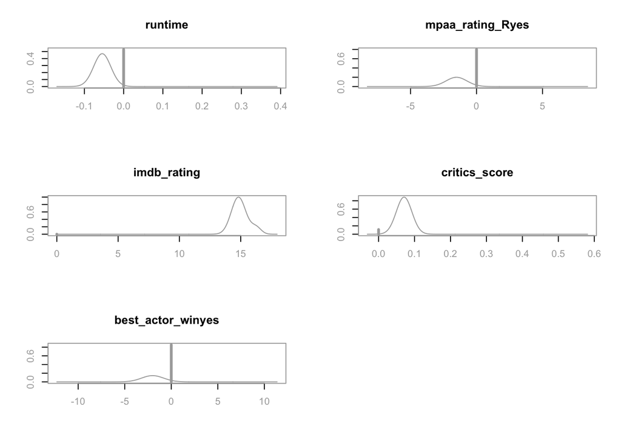

```r
coef_bma_audience <- coef(bma_audience)
par(mfrow = c(3, 2), col.lab = "darkgrey", col.axis = "darkgrey", col = "darkgrey")
plot(coef_bma_audience, subset=c(4,5,9,11,14), ask=FALSE)
```

For the prediction, we’ll use a subset of the data with just `runtime`, `imdb_rating`, `critics_score`, `mpaa_rating_R`, and `best_actor_win` to predict `audience_score`.

```r
movies_red <- movies_clean %>%
  select(runtime, imdb_rating, critics_score, mpaa_rating_R, best_actor_win, audience_score)
```

Our reduced model will use BMA with the non-informative prior on the regression coefficients.

```r
bma_audience_red <- bas.lm(audience_score ~ ., data = movies_red, prior = "BIC", modelprior = uniform())
summary(bma_audience_red)
```

```
##                   P(B != 0 | Y)    model 1       model 2       model 3
## Intercept             1.0000000     1.0000     1.0000000     1.0000000
## runtime               0.4731281     1.0000     0.0000000     0.0000000
## imdb_rating           1.0000000     1.0000     1.0000000     1.0000000
## critics_score         0.9026960     1.0000     1.0000000     1.0000000
## mpaa_rating_Ryes      0.2023162     0.0000     0.0000000     0.0000000
## best_actor_winyes     0.1494503     0.0000     0.0000000     1.0000000
## BF                           NA     1.0000     0.9968489     0.2543185
## PostProbs                    NA     0.3081     0.3071000     0.0784000
## R2                           NA     0.7549     0.7525000     0.7539000
## dim                          NA     4.0000     3.0000000     4.0000000
## logmarg                      NA -3615.2791 -3615.2822108 -3616.6482224
##                         model 4       model 5
## Intercept             1.0000000     1.0000000
## runtime               0.0000000     1.0000000
## imdb_rating           1.0000000     1.0000000
## critics_score         1.0000000     1.0000000
## mpaa_rating_Ryes      1.0000000     1.0000000
## best_actor_winyes     0.0000000     0.0000000
## BF                    0.2521327     0.2391994
## PostProbs             0.0777000     0.0737000
## R2                    0.7539000     0.7563000
## dim                   4.0000000     5.0000000
## logmarg           -3616.6568544 -3616.7095127
```

## Part 5: Prediction

We can then predict the `audience_score` from a movie released after 2016 (i.e. isn’t in the training set). I liked “Thor: Ragnarok”, so let’s pull down the data (manually) into a dataframe `thor_data`.

`runtime` = from Rottentomatoes, 130 minutes `imdb_rating` = from imdb, 7.9 `critics_score` = from Rottentomatoes, 93% `mpaa_rating_R` = from imdb, no `best_actor_win` = from imdb, yes. Sir Anthony Hopkins won Best Actor for *Silence of the Lambs* in 1992.

```r
thor_data <- data.frame(
  runtime = 130,
  imdb_rating = 7.9,
  critics_score = 93,
  mpaa_rating_R = "no",
  best_actor_win = "yes"
)
```

We’ll use simulation in `BAS` to build our predictive model, using the `BMA` estimator.

```r
BMA_pred_audience <- predict(bma_audience_red, estimator = "BMA", se.fit = TRUE, newdata = thor_data)
ci_bma_audience <- confint(BMA_pred_audience, estimator = "BMA")
opt_bma <- which.max(BMA_pred_audience$fit)
ci_bma_audience[opt_bma, ]
```

```
##      2.5%     97.5%      pred
##  65.31758 104.84639  85.00447
```

## Part 6: Conclusion

So using Bayesian Multiple Linear Regression, we were able to create a predictive model of the Rottentomatoes audience score given 5 different features of the movie with a 95% credible interval. We found that the most predictive features were the runtime, IMDB rating, critics’ score on Rottentomatoes, and whether or not the movie had an R rating and whether or not the movie had a leading actor who had previously won an Oscar for best actor/actress. However, this model incorporates information such as critics’ score and IMDB rating - features that would only be known after the movie has been released (or shortly before). So if we wanted to predict future movie success on an unreleased movie, we would only be able to predict audience score using the information that we have at the time (i.e. R rating, runtime, oscar winning actors).